# Population Structure Lab

Anusha Bishop

# Population Structure Analysis with TESS

Today we are going to analyze population structure in western fence lizards (*Sceloporus occidentalis*) using a method known as TESS (Caye et al., 2016). TESS is used to analyze population structure by estimating ancestry coefficients while taking into account geography. We will use the algatr package, which provides a user-friendly interface for running TESS, and also provides additional functionality for visualizing results.

First we need to load some libraries and install the required packages:

```r
library(algatr)
```

```r
# Install required packages
tess_packages()
```

```r
library(here)
library(wingen)
library(tess3r)
library(ggplot2)
library(terra)
library(raster)
library(fields)
library(automap)
library(cowplot)
library(sf)

# Colorblind friendly palette from https://personal.sron.nl/~pault/#sec:qualitative
pal <- function(n = 7){c('#EE7733', '#33BBEE', '#009988', '#EE3377', '#CC3311', '#0077BB', '#BBBBBB')[1:n]}
```

Let’s also load our data, which we will describe in more detail later:

```r
load_algatr_example()
```

```
##
## ---------------- example dataset ----------------
##
## Objects loaded:
## *liz_vcf* vcfR object (1000 loci x 53 samples)
## *liz_gendist* genetic distance matrix (Plink Distance)
## *liz_coords* dataframe with x and y coordinates
## *CA_env* RasterStack with example environmental layers
##
## -------------------------------------------------
```

## 1. Processing input data

Running TESS3 requires three data files: a genotype dosage matrix (the `gen` argument), coordinates for samples (the `coords` argument), and environmental layers (the `envlayers` argument). We can use a VCF and the `vcf_to_dosage()` function to convert a VCF file to a dosage matrix.

A dosage matrix includes counts of alleles at each locus. For the data we are working with, all of the loci are biallelic, meaning there are only two possible alleles at each locus: a reference allele and an alternate allele. For our purposes, there is no meaningful difference between the reference and the alternate allele. You can get dosage values of either 0, 1, or 2 whereby 0 represents no copies of the alternate allele, 1 represents one copy of the alternate allele, and 2 represents two copies of the alternate allele. For example, let’s say you have a reference allele “A” and an alternate allele “B”, we can represent the dosage values as follows: AA = 0 AB = 1 BB = 2

In our VCF, our genotypes are coded with 0 representing the reference (“A”) and 1 representing the alternate (“B”).

```r
# We can see the genotypes for the first 10 individuals and the first 10 loci using the following code:
liz_vcf@gt[1:10,1:10]
```

```
##       FORMAT ALT3  BAR360 BLL5  BNT5  BOF1  BOT3  CAR1  CTR7  CYR26
##  [1,] "GT"   "0/0" "0/0"  "0/0" "0/0" "0/0" "0/0" "0/0" "0/0" "0/0"
##  [2,] "GT"   "0/0" "0/0"  NA    "0/0" NA    "0/1" "0/0" "0/1" NA
##  [3,] "GT"   "0/0" "0/0"  "0/0" NA    NA    "0/0" NA    NA    NA
##  [4,] "GT"   "0/0" NA     "0/0" NA    NA    NA    NA    NA    NA
##  [5,] "GT"   "0/0" "0/0"  NA    "0/0" NA    "0/0" "0/0" "0/0" NA
##  [6,] "GT"   NA    "0/0"  "0/0" "0/0" NA    "0/0" "0/0" "0/0" "0/0"
##  [7,] "GT"   NA    "0/0"  "0/0" NA    "0/0" "0/0" "0/0" "0/0" "0/0"
##  [8,] "GT"   "1/1" "1/1"  "0/1" "0/0" "0/0" NA    "0/0" "0/0" "0/0"
##  [9,] "GT"   "0/0" "0/0"  NA    "0/0" NA    NA    "0/0" NA    NA
## [10,] "GT"   "0/0" "0/0"  "0/0" "0/0" "0/0" "0/0" "0/0" "0/0" "0/0"
```

```r
# Note that the rows are loci and the columns are individual lizards
```

Quesition 1: What would the dosage values be for the following genotypes?: “0/0” = ? “0/1” = ? “1/1” = ? “1/0” = ?

```r
# Convert vcf to genotype matrix
liz_dosage <- vcf_to_dosage(liz_vcf)
liz_dosage[1:10, 1:10]
```

```
##        Locus_10 Locus_15 Locus_22 Locus_28 Locus_32 Locus_35 Locus_37 Locus_61
## ALT3          0        0        0        0        0       NA       NA        2
## BAR360        0        0        0       NA        0        0        0        2
## BLL5          0       NA        0        0       NA        0        0        1
## BNT5          0        0       NA       NA        0        0       NA        0
## BOF1          0       NA       NA       NA       NA       NA        0        0
## BOT3          0        1        0       NA        0        0        0       NA
## CAR1          0        0       NA       NA        0        0        0        0
## CTR7          0        1       NA       NA        0        0        0        0
## CYR26         0       NA       NA       NA       NA        0        0        0
## FCT13         0        0        1       NA        0        0        0       NA
##        Locus_71 Locus_72
## ALT3          0        0
## BAR360        0        0
## BLL5         NA        0
## BNT5          0        0
## BOF1         NA        0
## BOT3         NA        0
## CAR1          0        0
## CTR7         NA        0
## CYR26        NA        0
## FCT13         1        0
```

```r
# Note that now the rows are individuals and the columns are loci
```

## 2. Running TESS

Population structure methods, such as TESS, describe genetic variation by assigning individuals to clusters. Individuals are given proportions to which they belong to each cluster. The number of clusters is oftern refered to as “K” and these proportions are known as ancestry coefficients, and can be interpreted as the proportion of an individual’s ancestry belonging to different ancestral groups. There are many methods for estimating these ancestry coefficients; TESS is a unique method because it takes into account geography by using sample coordinates to incorporate spatial relationships into ancestry coefficient estimates.

### K-selection

A crucial part of population structure analysis is choosing the best number of clusters (K) for the data. We can test a range of K values using the `tess_ktest()` function. `tess_ktest()` runs TESS for a range of K values and outputs cross-validation scores for each value which which we can use to evaluate the best K for their dataset. Typically, researchers will select the best K value by minimizing cross-validation scores. However, there is often not just one “best” K value, which you will see later on.

Here, we test K values 1 through 10. The `K_selection` argument specifies the method for selecting the best K value; we will be performing manual K selection. The `ploidy` argument specifies the ploidy of the data, which is 2 for our diploids.

**When we run the function, a cross-validation plot will appear and we will be prompted to select the best K value based on the cross-validation scores by entering a number in the console. If a plot does not appear, click on the settings cog (to the right of the “knit” button) and select `Chunk output in Console`**

How do you pick the best K-value? The cross-validation score is a measure of how well the model predicts the data. The lower the cross-validation score, the better the model is at predicting the data. However, as you will see, the cross-validation score tends to decrease as K increases because using more clusters to describe your sample often results in lower cross-validation error, so you want to pick the K value where the cross-validation score starts to level off. This is known as the “elbow” of the cross-validation plot.

```r
tess_test <- tess_ktest(liz_dosage, liz_coords, Kvals = 1:10, K_selection = "manual", ploidy = 2)
```

[output not shown]

### Looking at multiple values of K

```r
tess_result <- tess3(liz_dosage, coord = as.matrix(liz_coords), K = 1:10, ploidy = 2)
```

[output not shown]

The key output from TESS is a matrix of ancestry coefficients, also known as Q-values. These values represent the proportion of ancestry assigned to each individual for each cluster. We can extract these values using the `qmatrix()` function. Let’s extract the Q values for K = 2 through K = 6:

```r
qmat2 <- qmatrix(tess_result, K = 2)
qmat3 <- qmatrix(tess_result, K = 3)
qmat4 <- qmatrix(tess_result, K = 4)
qmat5 <- qmatrix(tess_result, K = 5)
qmat6 <- qmatrix(tess_result, K = 6)
```

We can visualize these Q values using a bar plot. The bar plot will show the proportion of ancestry assigned to each individual for each cluster (K value). Each bar represent an individual and the proportion of each color in the bar represents the proportion of ancestry for each individual. Let’s look at the bar plots for K = 2 through K = 6:

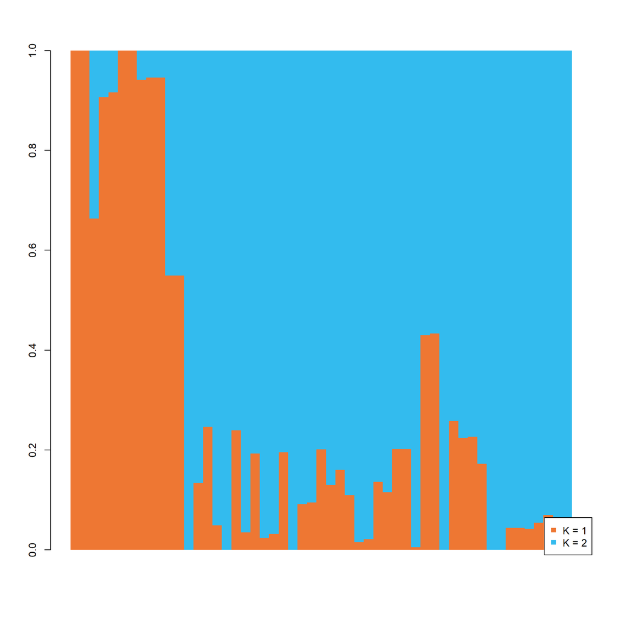

```
## $order
##  [1]  2 10 19 24 25 40 41 49 50 51 52 53  1  3  4  5  6  7  8  9 11 12 13 14 15
## [26] 16 17 18 20 21 22 23 26 27 28 29 30 31 32 33 34 35 36 37 38 39 42 43 44 45
## [51] 46 47 48
```

```r
tess_barplot(qmat2, col_pal = pal)
```

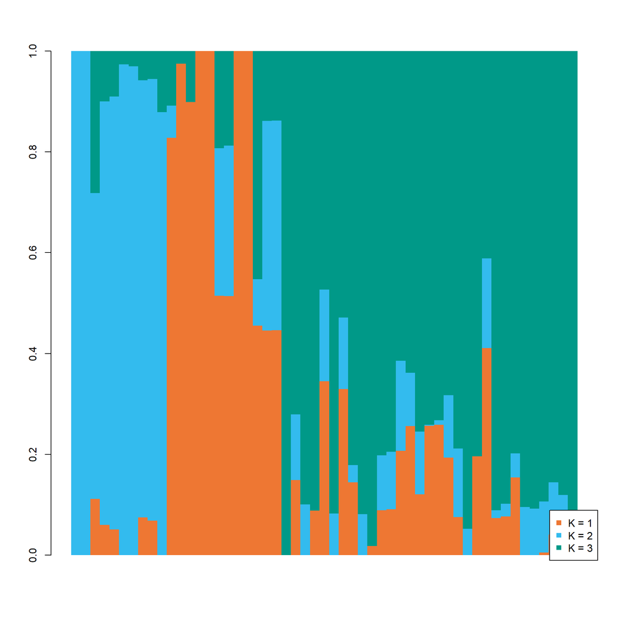

```
## $order
##  [1]  2 10 19 24 25 40 41 49 50 51  4 13 20 28 29 31 32 35 36 37 52 53  1  3  5
## [26]  6  7  8  9 11 12 14 15 16 17 18 21 22 23 26 27 30 33 34 38 39 42 43 44 45
## [51] 46 47 48
```

```r
tess_barplot(qmat3, col_pal = pal)
```

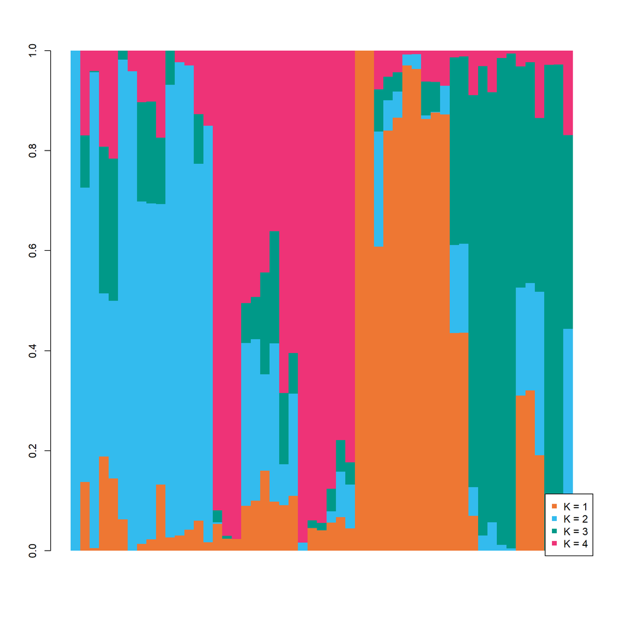

```
## $order
##  [1]  1  3  6  7  9 11 14 22 23 26 33 38 39 42 48  5  8 12 15 16 17 18 21 27 30
## [26] 43 44 45 46 47  2 10 19 24 25 40 41 49 50 51 52 53  4 13 20 28 29 31 32 34
## [51] 35 36 37
```

```r
tess_barplot(qmat4, col_pal = pal)
```

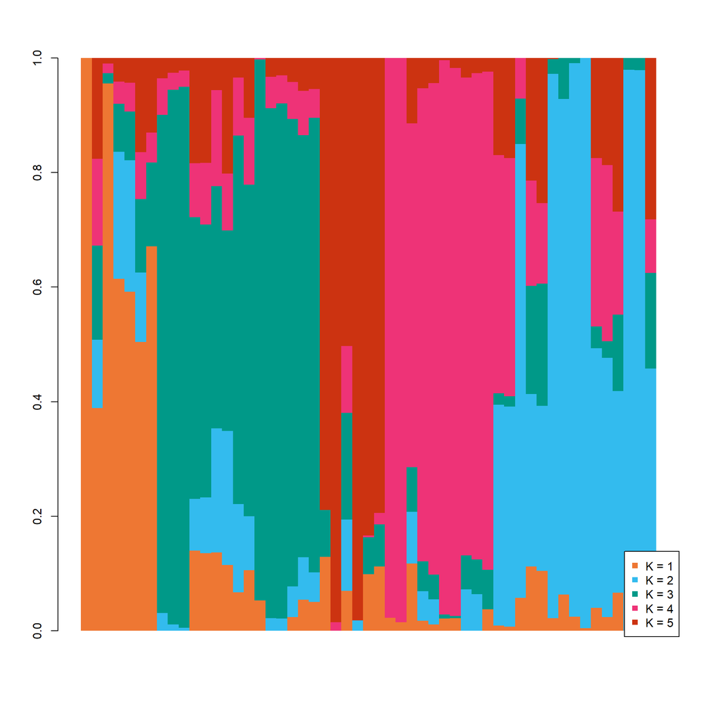

```
## $order
##  [1]  1  3 14 22 23 42 48  5  8 12 15 16 17 18 21 27 30 43 44 45 46 47  6 11 26
## [26] 33 38 39  2 10 19 24 25 40 41 49 50 51 52 53  4  7  9 13 20 28 29 31 32 34
## [51] 35 36 37
```

```r
tess_barplot(qmat5, col_pal = pal)
```

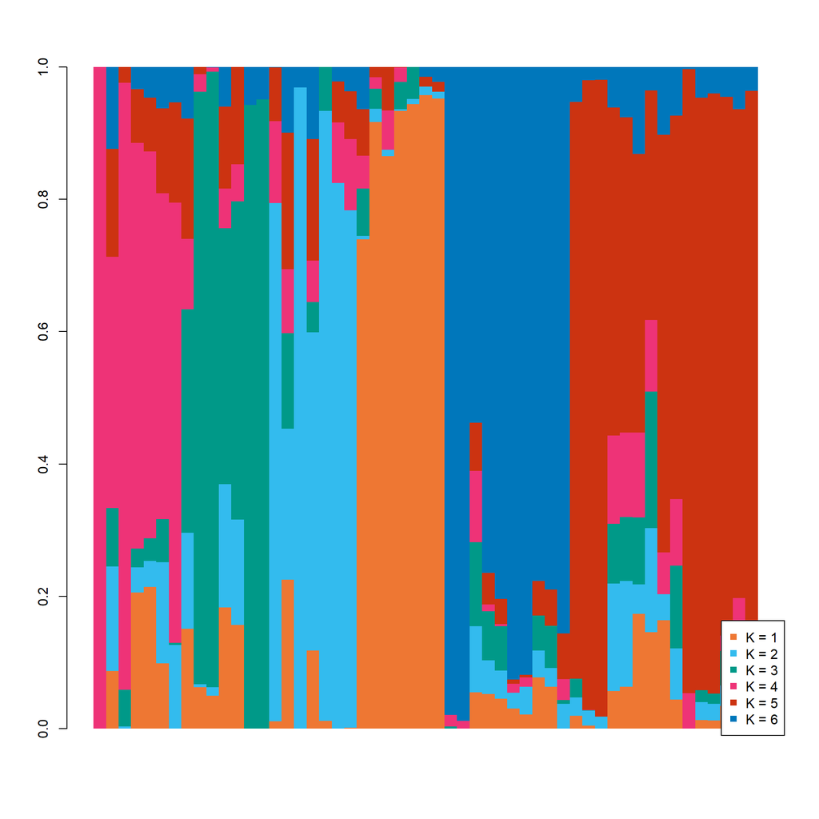

```
## $order
##  [1]  1  3 14 22 23 42 48  7 31 32 34 37 52 53  6  9 11 26 33 38 39  4 13 20 28
## [26] 29 35 36  2 10 19 24 25 40 41 49 50 51  5  8 12 15 16 17 18 21 27 30 43 44
## [51] 45 46 47
```

```r
tess_barplot(qmat6, col_pal = pal)
```

We can use the Q values to assign the individuals to clusters. We can do this by assigning each individual to the cluster with the highest Q value. Let’s assign the individuals to clusters for K = 3:

```r
# Assign individuals to clusters
clusters_k3 <- apply(qmat3, 1, which.max)
```

We can then plot the individuals on a map and color them by cluster. Let’s plot the individuals on a map and color them by cluster for K = 3:

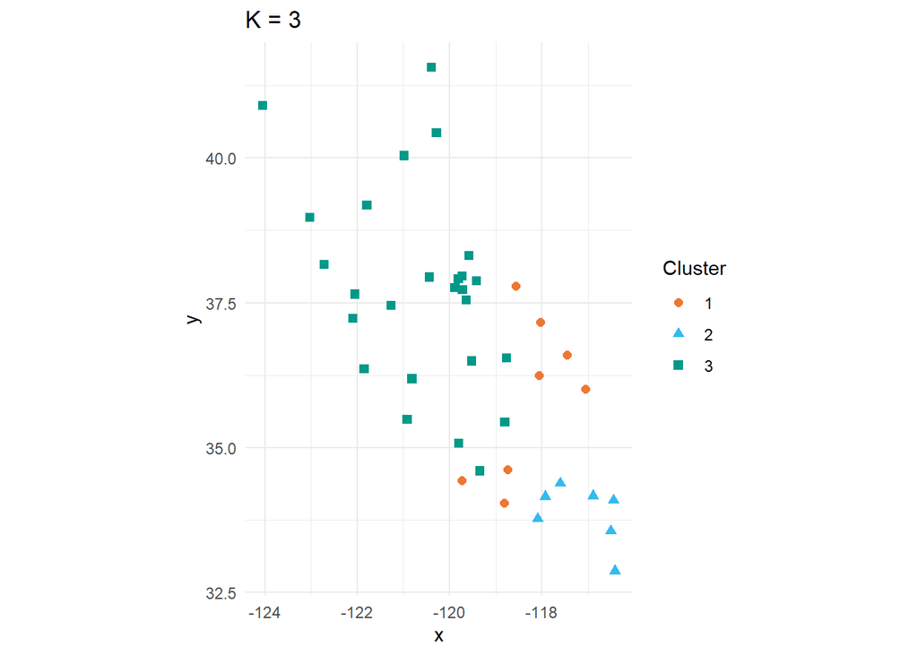

```r
ggplot() +
  geom_point(data = liz_coords, aes(x = x, y = y, color = factor(clusters_k3), pch = factor(clusters_k3)), size = 2) +
  theme_minimal() +
  labs(title = "K = 3", color = "Cluster", pch = "Cluster") +
  scale_color_manual(values = pal()) +
  coord_quickmap()
```

Let’s also look at other K values

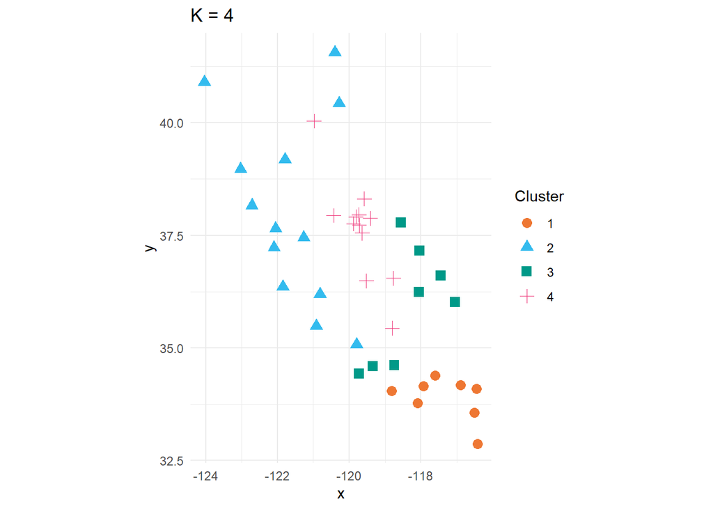

```r
clusters_k4 <- apply(qmat4, 1, which.max)
clusters_k5 <- apply(qmat5, 1, which.max)
clusters_k6 <- apply(qmat6, 1, which.max)

ggplot() +
  geom_point(data = liz_coords, aes(x = x, y = y, color = factor(clusters_k4), pch = factor(clusters_k4)), size = 3) +
  theme_minimal() +
  labs(title = "K = 4", color = "Cluster", pch = "Cluster") +
  scale_color_manual(values = pal()) +
  coord_quickmap()
```

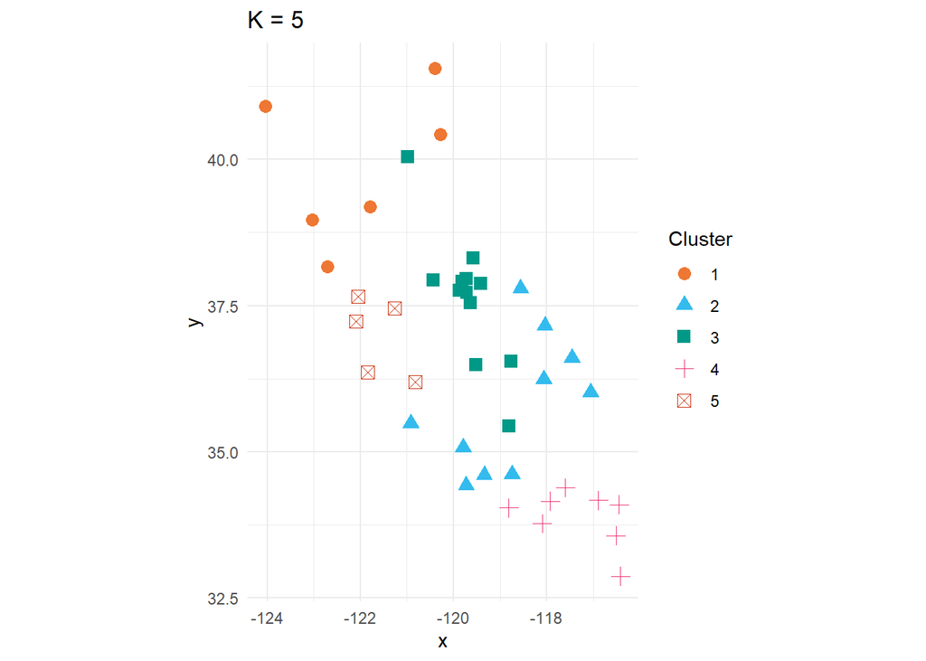

```r
ggplot() +
  geom_point(data = liz_coords, aes(x = x, y = y, color = factor(clusters_k5), pch = factor(clusters_k5)), size = 3) +
  theme_minimal() +
  labs(title = "K = 5", color = "Cluster", pch = "Cluster") +
  scale_color_manual(values = pal()) +
  coord_quickmap()
```

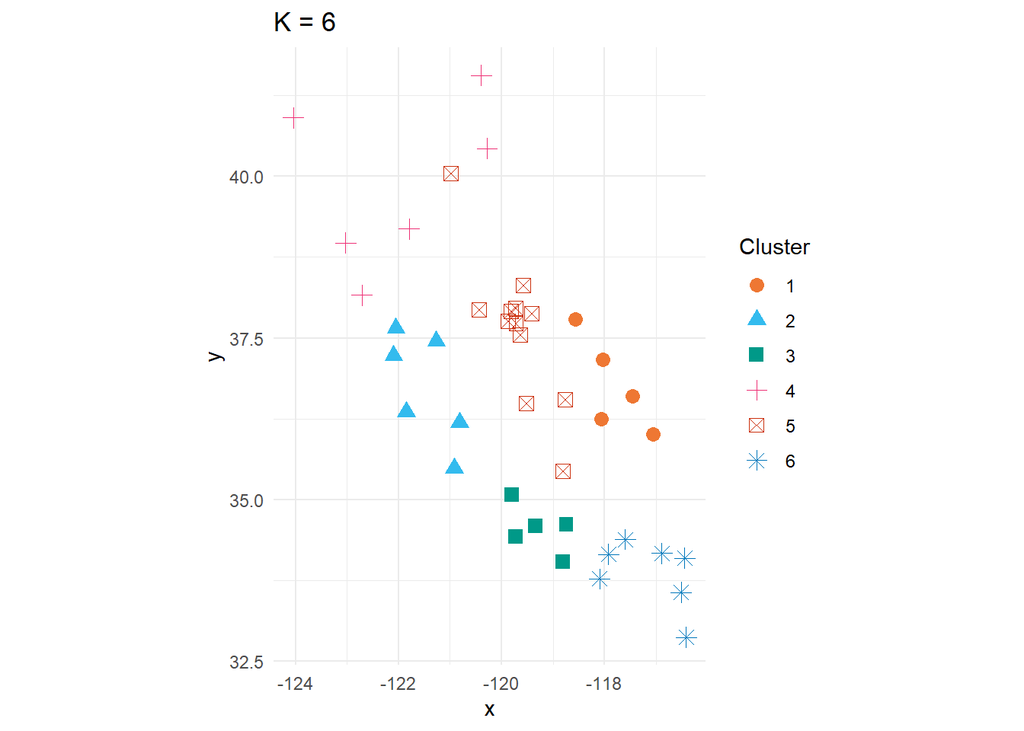

```r
ggplot() +
  geom_point(data = liz_coords, aes(x = x, y = y, color = factor(clusters_k6), pch = factor(clusters_k6)), size = 3) +
  theme_minimal() +
  labs(title = "K = 6", color = "Cluster", pch = "Cluster") +
  scale_color_manual(values = pal()) +
  coord_quickmap()
```

QUESTION 3: Another way we may try and assess the validity of clusters is whether they are geographically distinct; what this means is that individuals in the same cluster should be close to each other geographically. Based on this criteria, which K value do you think is the best? (You can pick multiple, you just need to provide a reason why you think those values are the best)

## 2. Interpolating ancestry coefficients across space

algatr can create maps of ancestry coefficient estimates using a method known as kriging, which uses a spatially explicit model for spatial interpolation.

The `tess_krig()` function will take in ancestry coefficient values (in the Q-matrix) and will krige the values based on the raster provided (`krig_raster` from above). This will produce a Raster* type object. First we need to do some manipulation of the coordinates to make sure they are in the correct projection.

```r
# We need a raster for kriging. I will use the first environmental layer from the example data
# We will also aggregate the raster to make it smaller and easier to work with
krig_raster <- raster::aggregate(CA_env[[1]], fact = 6)

# First, create sf coordinates (note: EPSG 4326 is WGS84/latitude-longitude)
coords_proj <- st_as_sf(liz_coords, coords = c("x", "y"), crs = 4326)

# Next, we project these coordinates to California Albers (EPSG 3310) since these coordinates are in California
coords_proj <- st_transform(coords_proj, crs = 3310)

# Finally, reproject the kriging raster to the same CRS as the coordinates
krig_raster <- projectRaster(krig_raster, crs = "epsg:3310")
# If you are using a SpatRaster you can reproject the coordinates like this:
# krig_raster <- terra::project(krig_raster, "epsg:3310")

# Now, we can run kriging using these coordinates
krig_admix <- tess_krig(qmat3, coords_proj, krig_raster)
```

Now, let’s explore how Q values (ancestry coefficients) are mapped. The `tess_ggplot()` function will take in the kriged admixture values and, using the “maxQ” option, we can plot only the maximum Q value for each cell.

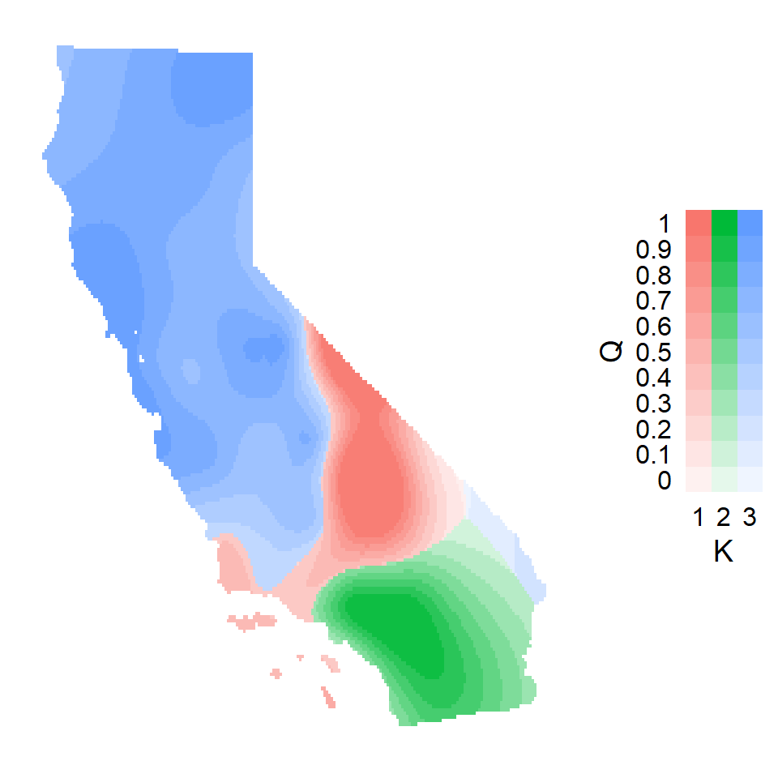

```r
tess_ggplot(krig_admix, plot_method = "maxQ", ggplot_fill = scale_color_manual(values = pal()))
```

QUESTION 4: What are some geographic features of California that might affect the population structure of western fence lizards? Do you see any patterns in the ancestry coefficients that might be related to these features? To help you answer this question, check out this guide to the California Geomorphic Provinces from the California Department of Conservation: https://www.conservation.ca.gov/cgs/Documents/Publications/CGS-Notes/CGS-Note-36.pdf You can also go on google maps and look at the terrain of California to get an idea of what the landscape looks like.

## ## Additional documentation and citations

1. **Main literature**: [Caye et al. 2016](https://onlinelibrary.wiley.com/doi/10.1111/1755-0998.12471); vignette available [here](https://bcm-uga.github.io/TESS3_encho_sen/articles/main-vignette.html)  
   Citation for TESS3
2. **Associated literature**: [François et al. 2006](https://academic.oup.com/genetics/article/174/2/805/6061653?login=false)  
   Details on algorithm used by TESS
3. **Associated literature**: [Chen et al. 2007](https://onlinelibrary.wiley.com/doi/10.1111/j.1471-8286.2007.01769.x)  
   Details on algorithm used by TESS
4. **Blog post**: [Automatic K selection](https://chazhyseni.github.io/NALgen/post/determining_bestk/)  
   Blog post on determining the best K